# Project Proposal - Speed Dating

#### Group 4

Group Members: Aikun Tao, Dantian Liu, Shaka Lohardjo, Xuefan Han, Zhilin Zhang

Instructor: Birol Emir

##### Introduction

We acquired data from Columbia Business School Professors Ray Fisman and Sheena Iyengar's speed dating experiment from 2002 to 2004. The data collects an individual's experience at a speed dating event. It also includes questionnaire data gathered throughout various stages of the event, during, halfway, few days after, and a few weeks after

## Data Cleaning and Preparation

### Installing Packages and Loading Data

```r
# install.packages('skimr')
# install.packages('tidyverse')
# install.packages('ggplot2')
# install.packages('ggcorrplot')
# install.packages('mice')
# install.packages('data.table')
# install.packages('FactoMineR')
# devtools::install_github("ricardo-bion/ggradar")
# install.packages('ggmisc')
# install.packages('gridExtra')
# devtools::install_github("MI2DataLab/randomForestExplainer")
# install.packages('caTools')

data_source = 'http://www.stat.columbia.edu/~gelman/arm/examples/speed.dating/'

options(repr.matrix.max.cols=200, repr.matrix.max.rows=200) #extend view of columns

#attaching packages
library(skimr)
library(ggpmisc)
library(dplyr)
library(ggplot2)
library(ggcorrplot)
library(gridExtra)
library(ggradar)
library(mice)
library(data.table)
library(tidyverse)
library(caret)
library(FactoMineR)
library(nnet)
library(caTools)
library(factoextra)
library(rpart)
library(rpart.plot)
library(randomForest)
library(ggthemes)
library(gbm)
library(randomForestExplainer)
```

```r
### load data to ensure loaded properly
path = 'Speed Dating Data.csv'
df = read.csv(path)
print(dim(df))
head(df)
```

```
[1] 8378  195
```

A data.frame: 6 × 195

|  | iid <int> | id <int> | gender <int> | idg <int> | condtn <int> | wave <int> | round <int> | position <int> | positin1 <int> | order <int> | partner <int> | pid <int> | match <int> | int_corr <dbl> | samerace <int> | age_o <int> | race_o <int> | pf_o_att <dbl> | pf_o_sin <dbl> | pf_o_int <dbl> | pf_o_fun <dbl> | pf_o_amb <dbl> | pf_o_sha <dbl> | dec_o <int> | attr_o <dbl> | sinc_o <dbl> | intel_o <dbl> | fun_o <dbl> | amb_o <dbl> | … |
| --- | --- | --- | --- | --- | --- | --- | --- | --- | --- | --- | --- | --- | --- | --- | --- | --- | --- | --- | --- | --- | --- | --- | --- | --- | --- | --- | --- | --- | --- | --- |
| 1 | 1 | 1 | 0 | 1 | 1 | 1 | 10 | 7 | NA | 4 | 1 | 11 | 0 | 0.14 | 0 | 27 | 2 | 35 | 20 | 20 | 20 | 0 | 5 | 0 | 6 | 8 | 8 | 8 | 8 | … |
| 2 | 1 | 1 | 0 | 1 | 1 | 1 | 10 | 7 | NA | 3 | 2 | 12 | 0 | 0.54 | 0 | 22 | 2 | 60 | 0 | 0 | 40 | 0 | 0 | 0 | 7 | 8 | 10 | 7 | 7 | … |
| 3 | 1 | 1 | 0 | 1 | 1 | 1 | 10 | 7 | NA | 10 | 3 | 13 | 1 | 0.16 | 1 | 22 | 4 | 19 | 18 | 19 | 18 | 14 | 12 | 1 | 10 | 10 | 10 | 10 | 10 | … |
| 4 | 1 | 1 | 0 | 1 | 1 | 1 | 10 | 7 | NA | 5 | 4 | 14 | 1 | 0.61 | 0 | 23 | 2 | 30 | 5 | 15 | 40 | 5 | 5 | 1 | 7 | 8 | 9 | 8 | 9 | … |
| 5 | 1 | 1 | 0 | 1 | 1 | 1 | 10 | 7 | NA | 7 | 5 | 15 | 1 | 0.21 | 0 | 24 | 3 | 30 | 10 | 20 | 10 | 10 | 20 | 1 | 8 | 7 | 9 | 6 | 9 | … |
| 6 | 1 | 1 | 0 | 1 | 1 | 1 | 10 | 7 | NA | 6 | 6 | 16 | 0 | 0.25 | 0 | 25 | 2 | 50 | 0 | 30 | 10 | 0 | 10 | 1 | 7 | 7 | 8 | 8 | 7 | … |

### Initial Review - Thoughts and Data Cleaning

The data has 8378 rows and 195 columns. Reviewing the first few rows, it seems that each row represents a date for a particular individual and it repeats for every date that person has. Then it shows the repeated characteristics of the individual for their own perception or characteristics for every speed date they have. There are some considerations with this data structure, there may be users with varying frequencies of dates of results and for empty values of same individuals could be imputed. For each date, they score their date and determine if they are a match (1 for yes and 0 for no). There are some demographic of the individual and the potential speed date. The data collects characteristic qualities: Attractive, Sincere, Intelligent, Fun, Ambitious, Has shared interests/hobbies that the individual rates others and themselves. We can potentially separate these for different use cases as well as make comparisons between individual's personal ratings and the partner's ratings.

Due to the size, we need to review the summary statistics on skimr to identify the distribution and null values. Moreover, we will attempt several different methods to reduce the number of columns to make it simple. First, reading the key list, we determine the relevant data that could provide insights and remove potential duplicates to reduce the number of columns. Second, we will subset the data for different use case. Between the subsets we can review the highly correlated data and remove them. Then, we can also decide on inputing missing values if it makes sense. Finally, for values we cannot impute, we will remove the rows with many missing values.

```r
### skim package to view summary statistics
skim(df)
```

```
── Data Summary ────────────────────────
                           Values
Name                       df
Number of rows             8378
Number of columns          195
_______________________
Column type frequency:
  character                8
  numeric                  187
________________________
Group variables            None

── Variable type: character ────────────────────────────────────────────────────
  skim_variable n_missing complete_rate   min   max empty n_unique whitespace
1 field                 0             1     0    56    63      260          0
```

[output cut: 385 more lines]

### Important Feature Descriptions and Explanation

##### Unique Identifiers

- iid: subject number and group (wave id and gender)
- pid: partner's id

##### Study Setting

- Wave: Grouping for the set of individuals at the speed dating event. Wave 6-9 has a 10 scale (changed to 100 pt scale by proportion), remainder has 100 pt allocation. Each wave has different number of male and female.
- match: 1 = yes, 0 = no - individual's decision on whether they like the date
- match_o: 1 = yes, 0 = no - partner's decision on whether they like the date
- dec: Decision 1= yes, 0 = no - to a date between two indivdiuals by the individual
- samerace: participant and the partner were the same race. 1= yes, 0=no
- met: how many times they met before

#### Person's Data

##### Demographic Data

- gender: female = 0, male = 0
- age: age of the individual
- from: city/country prior to Columbia
- race: racial identity coded
- field: field of study
- field_cd: code for field of study
- career: potential or current industry intended to work in
- career_c: career coded into general categories
- zipcode: zipcode of growth

##### Psychographic Data

- Goal: Described intention of what they go to the event for the event
- date: frequency of going on a date categorized
- go_out: frequency of going out (not necessarily dates)
- imprace: importance on a scale of 1 - 10, same race/ethnic background
- imprelig: importance on a scale of 1 - 10, same relgion
- Activities (scale of 1 - 10): sports, tvsports, excersice, dining, museums, art, hiking, gaming, clubbing, reading, tv, theater, movies, concerts, music, shopping, yoga
- Exphappy: expectation of happiness with the people met at the event on a scale of 1 - 10
- Expnum: expectation of number of interested dates
- Match_es: expectation of the number of matches

#### Partner's Data

Partner's fields are denoted with "_o"

##### Unique Identifiers

- pid: partner’s iid number

##### Demographic Data

- age_o: age of partner
- race_o: race of partner
- pf_o_att: partner’s stated preference at Time 1 (attr1_1) for all 6 characteristics (see Characteristics Key section)
- attr_o: rating by partner the night of the event, for all 6 characteristics (see Characteristics Key section)

#### Characteristics Keys

Characteristics that need to add up to 100 defining the most important - attr1_1 - Attractive, sinc1_1 - Sincere, intel1_1 - Intelligent, fun1_1 - Fun, amb1_1 - Ambitious, shar1_1 - Has shared interests/hobbies

```
- Identify most popular types of characteristics perceptions
```

- Different keys for characteristics: characterx_y, (x = key, y = period asked{1:"During event", 2: "days after event", 3: "weeks after sent matches"})
  - sinc1_1 - represent one's own perception on important of sincerity
  - sinc2_1 - represents one's perception on partner's important of sincerity
  - sinc3_1 - represents one's opinion on how they measure up on sincerity
  - sinc4_1 - represents one's opinion on how others perceive you on sincerity

### Data Exploration - Demographic Data & Study Participants

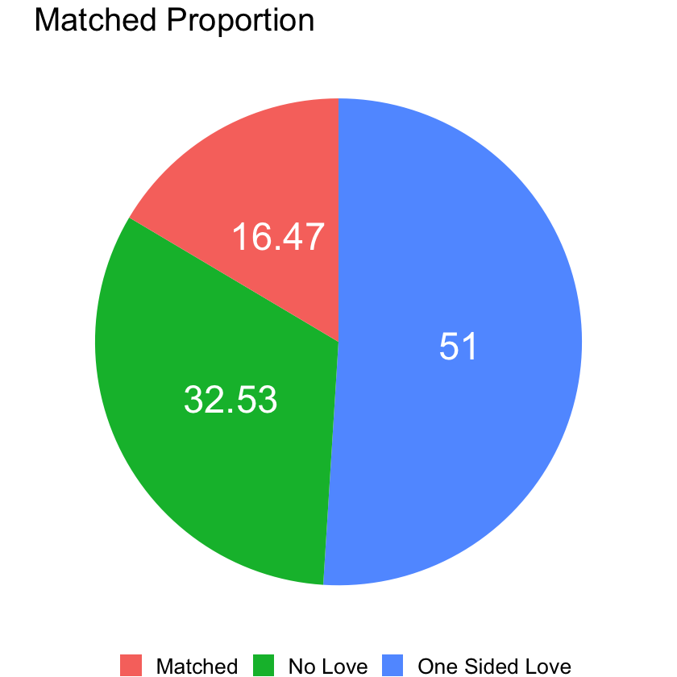

```r
### Match & Decision by Partner and Person
df %>%
    select(pid,dec,dec_o,match) %>%
    mutate(decision = case_when(
        dec == 1 & dec_o == 1 & match == 1      ~ "Matched",
        (dec == 1 | dec_o == 1) & match == 1    ~ "One Sided Love",
        dec == 1 & dec_o == 1 & match == 0      ~ "One Sided Love",
        (dec == 1 | dec_o == 1) & match == 0    ~ "One Sided Love",
        TRUE                                    ~ "No Love"
    )) %>%
    group_by(decision) %>%
    count() %>%
    ungroup() %>%
    arrange(desc(decision))%>%
    mutate(col_percent = round(100*n/sum(n),2)) %>%
    mutate(ypos = cumsum(col_percent)- 0.5*col_percent) %>%
    # ungroup()
    ggplot(., aes(x = "", y= col_percent, fill=decision)) +

    geom_bar(stat="identity", width = 1) +
    coord_polar("y", start = 0) +
    theme_void() +
    geom_text(aes(y = ypos, label = col_percent), color = "white", size=10)+
    theme(legend.position = 'bottom', text = element_text(size = 20), legend.title = element_blank()) +
    ggtitle("Matched Proportion")
```

```r
### field distribution vs field_cd
# ggplot(data=df, mapping = aes(x=field_cd)) +
#     geom_bar()
```

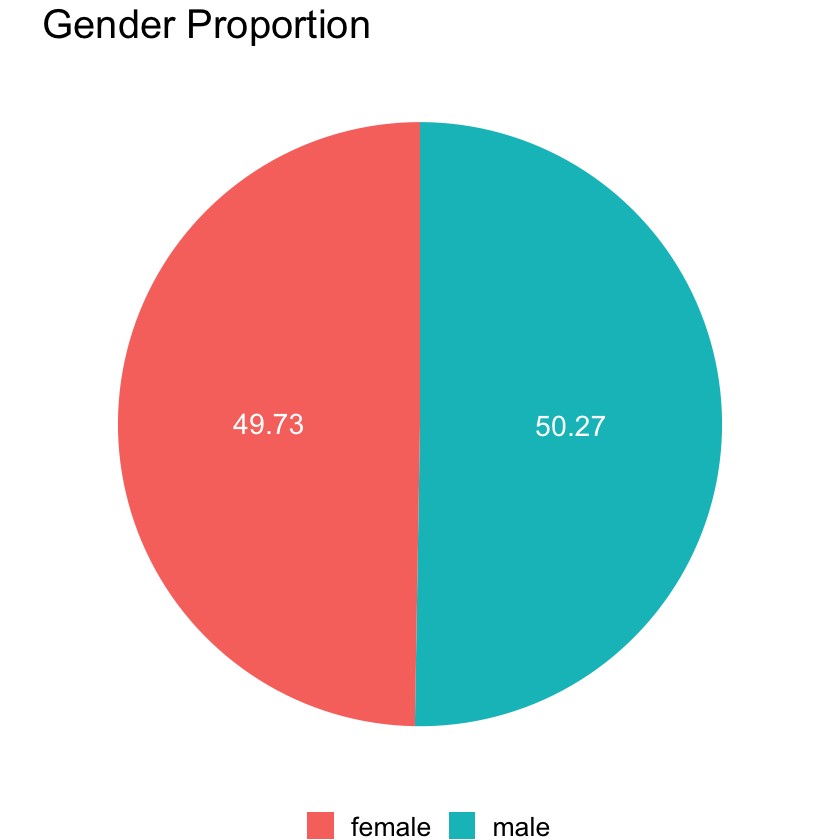

```r
### Proportion of Participant's Gender
df %>%
    select(iid,gender) %>%
    filter(!duplicated(iid)) %>%
    mutate(gender = case_when(
        gender == 0 ~ "female",
        gender == 1 ~ "male",
        TRUE ~ "prefer_not_to_disclose"
    )) %>%
    group_by(gender) %>%
    count() %>%
    ungroup() %>%
    arrange(desc(gender))%>%
    mutate(col_percent = round(100*n/sum(n),2)) %>%
    mutate(ypos = cumsum(col_percent)- 0.5*col_percent) %>%
    ggplot(., aes(x = "", y= col_percent, fill=gender)) +
        geom_bar(stat="identity", width = 1) +
        coord_polar("y", start = 0) +
        theme_void() +
        geom_text(aes(y = ypos, label = col_percent), color = "white", size=6) +
        theme(text = element_text(size = 20), legend.position = "bottom", legend.title = element_blank()) +
        ggtitle("Gender Proportion")
```

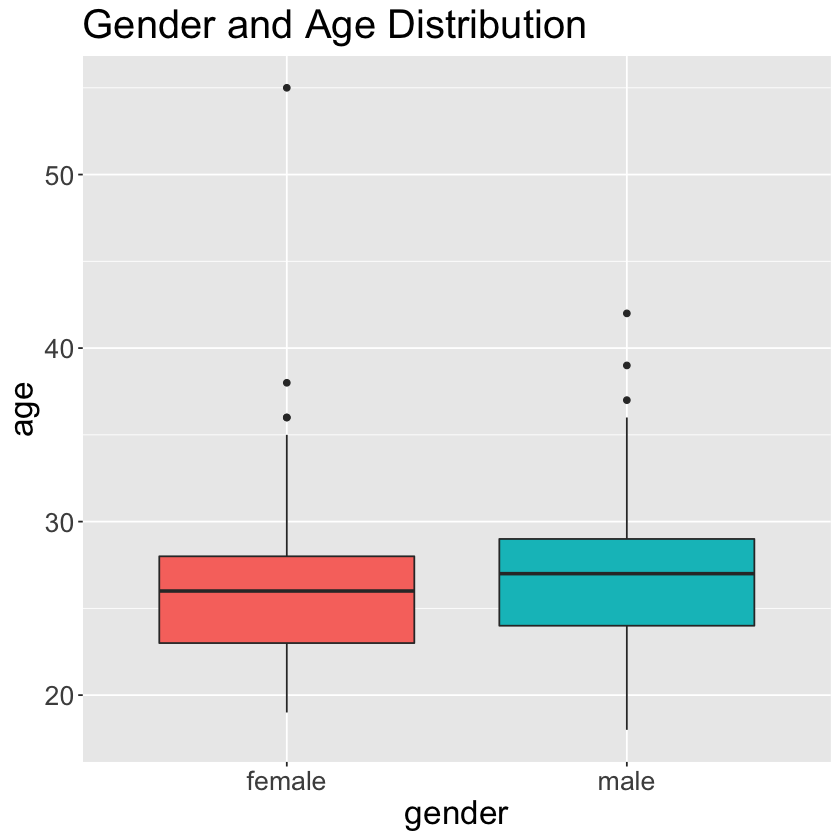

```r
### Age Distribution
df %>%
    select(iid,gender,age) %>%
    filter(!duplicated(iid)) %>%
    mutate(gender = case_when(
        gender == 0 ~ "female",
        gender == 1 ~ "male",
        TRUE ~ "prefer_not_to_disclose"
    )) %>%
    ggplot(., aes(x=gender, y= age , fill=gender)) +
        geom_boxplot() +
        theme(text = element_text(size = 20), legend.position = "none") +
        ggtitle("Gender and Age Distribution")
```

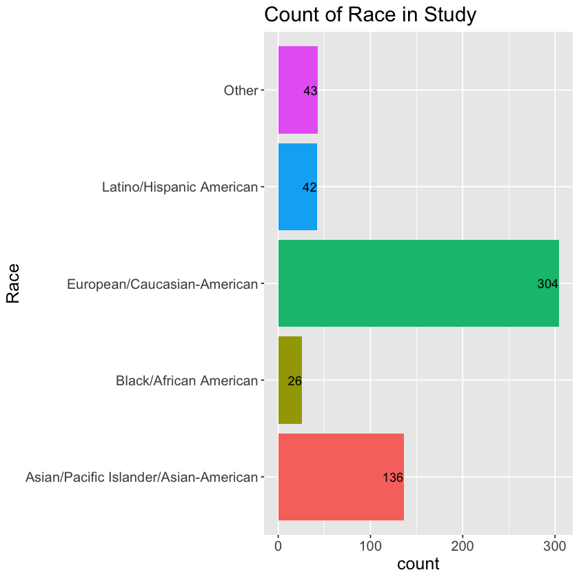

```r
### Distribution of Race
df %>%
    select(iid, race) %>%
    filter(!duplicated(iid)) %>%
    mutate(race = case_when(
        race == 1 ~ "Black/African American",
        race == 2 ~ "European/Caucasian-American",
        race == 3 ~ "Latino/Hispanic American",
        race == 4 ~ "Asian/Pacific Islander/Asian-American",
        race == 5 ~ "Native American",
        TRUE ~ "Other" )) %>%
    # filter(dec_o == 1) %>%
    ggplot(., aes(x=factor(race), fill = factor(race))) +
        geom_bar() +
        geom_text(aes(label= ..count..), stat = "count", hjust = 1)+
        coord_flip() +
        theme(legend.position = "none",
            text = element_text(size = 15)) +
        ggtitle("Count of Race in Study") +
        xlab('Race')
```

### Data Cleaning - Considerations for cleaning and removal:

- Duplicate fields removal (if any)
- Imputing data entry mistakes (if any)
- Columns with many null values
- Separate by survey time periods - Subset:
  - Halfway through the event request for importance in attributes in a potential date (ends with "1_s"), and your own attribute (ends with "3_s")
  - Followup/Time2 - correspond with a survey days after the event, to receive the matches (marked with "x_2" original keys during event and 2 at the end). Do we care if they reply after the event or do we care about on the event?
  - Followup2/Time3 - correspond with a survey weeks after they receive matches (marked with "x_3" at the end). Do we care if they reply after the event or do we care about on the event?
- Fortunately, the skim shows that the values are within their proper ranges with no extreme outliers for the values

```r
# writing vectors of data_groupings
personal = c("match",
            "gender", "age",
            "field_cd","race", "imprace",
            "imprelig", "zipcode",
            "income", "goal", "date",
            "go_out", "career_c",
            "sports", "tvsports", "exercise",
            "attr","sinc",
            "intel","fun","amb",
            "shar","like","prob","met",
            "dining", "museums", "art",
            "hiking", "gaming", "clubbing",
            "reading", "tv", "theater",
            "movies", "concerts", "music",
            "shopping", "yoga", "exphappy",
            "expnum", "match_es")

partner = c(
            "age_o","race_o",
            "attr_o","sinc_o","intel_o",
            "fun_o","amb_o","shar_o",
            "like_o","prob_o","met_o","go_out")

id_fields = c("pid", "iid")

### Pre-select data to remove due to high null values or unimportant to final analysis
# remove_data = c( "undergra", "mn_sat", "tuition", "income", "positin1", "expnum")
```

```r
### checking for duplicated rows -- Great! No Duplicate Rows
sum(duplicated(df))
```

0

```r
### imputing data that should be duplicated -- Great! All fields are properly inputed with the same personal information
df %>%
    select(iid, any_of(personal)) %>%
    filter(!duplicated(iid)) %>%
    group_by(iid) %>%
    count() %>%
    filter(n>1)
```

A grouped_df: 0 × 2

| iid | n |
| --- | --- |
| <int> | <int> |

#### Subsetting Data

Given our use cases is mainly focused on the individual during the event, we will exclude the features that are only relevant to the individual and partner's characteristics.

```r
#creating a subset from the dataset to use for final analysis
personal_df <- df %>%
    select(any_of(append(personal,partner)))
dim(personal_df)
head(personal_df)
```

1. 8378

2. 53

A data.frame: 6 × 53

|  | match <int> | gender <int> | age <int> | field_cd <dbl> | race <int> | imprace <int> | imprelig <int> | zipcode <chr> | income <chr> | goal <int> | date <int> | go_out <int> | career_c <dbl> | sports <int> | tvsports <int> | exercise <int> | attr <dbl> | sinc <dbl> | intel <dbl> | fun <dbl> | amb <dbl> | shar <dbl> | like <dbl> | prob <dbl> | met <int> | dining <int> | museums <int> | art <int> | hiking <int> | … |
| --- | --- | --- | --- | --- | --- | --- | --- | --- | --- | --- | --- | --- | --- | --- | --- | --- | --- | --- | --- | --- | --- | --- | --- | --- | --- | --- | --- | --- | --- | --- |
| 1 | 0 | 0 | 21 | 1 | 4 | 2 | 4 | 60,521 | 69,487.00 | 2 | 7 | 1 | NA | 9 | 2 | 8 | 6 | 9 | 7 | 7 | 6 | 5 | 7 | 6 | 2 | 9 | 1 | 1 | 5 | … |
| 2 | 0 | 0 | 21 | 1 | 4 | 2 | 4 | 60,521 | 69,487.00 | 2 | 7 | 1 | NA | 9 | 2 | 8 | 7 | 8 | 7 | 8 | 5 | 6 | 7 | 5 | 1 | 9 | 1 | 1 | 5 | … |
| 3 | 1 | 0 | 21 | 1 | 4 | 2 | 4 | 60,521 | 69,487.00 | 2 | 7 | 1 | NA | 9 | 2 | 8 | 5 | 8 | 9 | 8 | 5 | 7 | 7 | NA | 1 | 9 | 1 | 1 | 5 | … |
| 4 | 1 | 0 | 21 | 1 | 4 | 2 | 4 | 60,521 | 69,487.00 | 2 | 7 | 1 | NA | 9 | 2 | 8 | 7 | 6 | 8 | 7 | 6 | 8 | 7 | 6 | 2 | 9 | 1 | 1 | 5 | … |
| 5 | 1 | 0 | 21 | 1 | 4 | 2 | 4 | 60,521 | 69,487.00 | 2 | 7 | 1 | NA | 9 | 2 | 8 | 5 | 6 | 7 | 7 | 6 | 6 | 6 | 6 | 2 | 9 | 1 | 1 | 5 | … |
| 6 | 0 | 0 | 21 | 1 | 4 | 2 | 4 | 60,521 | 69,487.00 | 2 | 7 | 1 | NA | 9 | 2 | 8 | 4 | 9 | 7 | 4 | 6 | 4 | 6 | 5 | 2 | 9 | 1 | 1 | 5 | … |

```r
### removing columns with more than 1000 null values cutting the number of columns from 61 -> 55
dim(personal_df)
personal_df <- personal_df[, colSums(is.na(personal_df))<1000]
personal_df <- personal_df %>%
                select(!contains(c("zipcode", "income")))
dim(personal_df)
head(personal_df)
```

1. 8378

2. 53

1. 8378

2. 47

A data.frame: 6 × 47

|  | match <int> | gender <int> | age <int> | field_cd <dbl> | race <int> | imprace <int> | imprelig <int> | goal <int> | date <int> | go_out <int> | career_c <dbl> | sports <int> | tvsports <int> | exercise <int> | attr <dbl> | sinc <dbl> | intel <dbl> | fun <dbl> | amb <dbl> | like <dbl> | prob <dbl> | met <int> | dining <int> | museums <int> | art <int> | hiking <int> | gaming <int> | clubbing <int> | reading <int> | … |
| --- | --- | --- | --- | --- | --- | --- | --- | --- | --- | --- | --- | --- | --- | --- | --- | --- | --- | --- | --- | --- | --- | --- | --- | --- | --- | --- | --- | --- | --- | --- |
| 1 | 0 | 0 | 21 | 1 | 4 | 2 | 4 | 2 | 7 | 1 | NA | 9 | 2 | 8 | 6 | 9 | 7 | 7 | 6 | 7 | 6 | 2 | 9 | 1 | 1 | 5 | 1 | 5 | 6 | … |
| 2 | 0 | 0 | 21 | 1 | 4 | 2 | 4 | 2 | 7 | 1 | NA | 9 | 2 | 8 | 7 | 8 | 7 | 8 | 5 | 7 | 5 | 1 | 9 | 1 | 1 | 5 | 1 | 5 | 6 | … |
| 3 | 1 | 0 | 21 | 1 | 4 | 2 | 4 | 2 | 7 | 1 | NA | 9 | 2 | 8 | 5 | 8 | 9 | 8 | 5 | 7 | NA | 1 | 9 | 1 | 1 | 5 | 1 | 5 | 6 | … |
| 4 | 1 | 0 | 21 | 1 | 4 | 2 | 4 | 2 | 7 | 1 | NA | 9 | 2 | 8 | 7 | 6 | 8 | 7 | 6 | 7 | 6 | 2 | 9 | 1 | 1 | 5 | 1 | 5 | 6 | … |
| 5 | 1 | 0 | 21 | 1 | 4 | 2 | 4 | 2 | 7 | 1 | NA | 9 | 2 | 8 | 5 | 6 | 7 | 7 | 6 | 6 | 6 | 2 | 9 | 1 | 1 | 5 | 1 | 5 | 6 | … |
| 6 | 0 | 0 | 21 | 1 | 4 | 2 | 4 | 2 | 7 | 1 | NA | 9 | 2 | 8 | 4 | 9 | 7 | 4 | 6 | 6 | 5 | 2 | 9 | 1 | 1 | 5 | 1 | 5 | 6 | … |

```r
### function for calculating mode
calc_mode <- function(x){

  # List the distinct / unique values
  distinct_values <- unique(x)

  # Count the occurrence of each distinct value
  distinct_tabulate <- tabulate(match(x, distinct_values))

  # Return the value with the highest occurrence
  distinct_values[which.max(distinct_tabulate)]
}
```

```r
### consistency in cases for string fields
# personal_df <- personal_df %>%
#                 mutate(
#                   field_cd = tolower(field),
#                         from = tolower(from),
#                         career_c = tolower(career))

factor_col = c('field_cd', 'career_c', 'match', 'race', 'gender')

personal_df[factor_col] <- lapply(personal_df[factor_col], factor)

### replacing empty character values with NA for imputation with mode
personal_df[personal_df == ''] <- NA
personal_df <- personal_df %>%
  mutate(across(c('field_cd', 'career_c'), ~replace_na(.x, calc_mode(.x))))
skim(personal_df)
```

```
── Data Summary ────────────────────────
                           Values
Name                       personal_df
Number of rows             8378
Number of columns          47
_______________________
Column type frequency:
  factor                   5
  numeric                  42
________________________
Group variables            None

── Variable type: factor ───────────────────────────────────────────────────────
  skim_variable n_missing complete_rate ordered n_unique
1 match                 0         1     FALSE          2
```

[output cut: 98 more lines]

```r
### impute the missing data with mice
personal_mice = mice::complete(mice(personal_df,seed = 123))
```

```r
head(personal_mice)
```

A data.frame: 6 × 47

|  | match <fct> | gender <fct> | age <int> | field_cd <fct> | race <fct> | imprace <int> | imprelig <int> | goal <int> | date <int> | go_out <int> | career_c <fct> | sports <int> | tvsports <int> | exercise <int> | attr <dbl> | sinc <dbl> | intel <dbl> | fun <dbl> | amb <dbl> | like <dbl> | prob <dbl> | met <int> | dining <int> | museums <int> | art <int> | hiking <int> | gaming <int> | clubbing <int> | reading <int> | … |
| --- | --- | --- | --- | --- | --- | --- | --- | --- | --- | --- | --- | --- | --- | --- | --- | --- | --- | --- | --- | --- | --- | --- | --- | --- | --- | --- | --- | --- | --- | --- |
| 1 | 0 | 0 | 21 | 1 | 4 | 2 | 4 | 2 | 7 | 1 | 2 | 9 | 2 | 8 | 6 | 9 | 7 | 7 | 6 | 7 | 6 | 2 | 9 | 1 | 1 | 5 | 1 | 5 | 6 | … |
| 2 | 0 | 0 | 21 | 1 | 4 | 2 | 4 | 2 | 7 | 1 | 2 | 9 | 2 | 8 | 7 | 8 | 7 | 8 | 5 | 7 | 5 | 1 | 9 | 1 | 1 | 5 | 1 | 5 | 6 | … |
| 3 | 1 | 0 | 21 | 1 | 4 | 2 | 4 | 2 | 7 | 1 | 2 | 9 | 2 | 8 | 5 | 8 | 9 | 8 | 5 | 7 | 5 | 1 | 9 | 1 | 1 | 5 | 1 | 5 | 6 | … |
| 4 | 1 | 0 | 21 | 1 | 4 | 2 | 4 | 2 | 7 | 1 | 2 | 9 | 2 | 8 | 7 | 6 | 8 | 7 | 6 | 7 | 6 | 2 | 9 | 1 | 1 | 5 | 1 | 5 | 6 | … |
| 5 | 1 | 0 | 21 | 1 | 4 | 2 | 4 | 2 | 7 | 1 | 2 | 9 | 2 | 8 | 5 | 6 | 7 | 7 | 6 | 6 | 6 | 2 | 9 | 1 | 1 | 5 | 1 | 5 | 6 | … |
| 6 | 0 | 0 | 21 | 1 | 4 | 2 | 4 | 2 | 7 | 1 | 2 | 9 | 2 | 8 | 4 | 9 | 7 | 4 | 6 | 6 | 5 | 2 | 9 | 1 | 1 | 5 | 1 | 5 | 6 | … |

## Dimension Reduction

#### Variable Importance

To reduce the number of variables we can conduct variable importance or principle component analysis

```r
tree1 = rpart(match~., data = personal_df, method = 'class')
var_importance <- tibble::rownames_to_column(data.frame(tree1$variable.importance), 'variables')
var_importance
```

A data.frame: 12 × 2

| variables <chr> | tree1.variable.importance <dbl> |
| --- | --- |
| like_o | 189.62097 |
| like | 188.17105 |
| attr | 121.07047 |
| fun | 97.35299 |
| attr_o | 89.72151 |
| fun_o | 87.54267 |
| prob_o | 86.26018 |
| sinc | 62.96218 |
| intel | 61.53122 |
| sinc_o | 56.58380 |
| prob | 54.78527 |
| intel_o | 51.05774 |

```r
important_variables <-  var_importance$variables

var_importance_df <- personal_mice[important_variables]
final_vi_data <- cbind(var_importance_df, personal_mice['match'])
head(final_vi_data)
```

A data.frame: 6 × 13

|  | like_o <dbl> | like <dbl> | attr <dbl> | fun <dbl> | attr_o <dbl> | fun_o <dbl> | prob_o <dbl> | sinc <dbl> | intel <dbl> | sinc_o <dbl> | prob <dbl> | intel_o <dbl> | match <fct> |
| --- | --- | --- | --- | --- | --- | --- | --- | --- | --- | --- | --- | --- | --- |
| 1 | 7 | 7 | 6 | 7 | 6 | 8 | 4 | 9 | 7 | 8 | 6 | 8 | 0 |
| 2 | 8 | 7 | 7 | 8 | 7 | 7 | 4 | 8 | 7 | 8 | 5 | 10 | 0 |
| 3 | 10 | 7 | 5 | 8 | 10 | 10 | 10 | 8 | 9 | 10 | 5 | 10 | 1 |
| 4 | 7 | 7 | 7 | 7 | 7 | 8 | 7 | 6 | 8 | 8 | 6 | 9 | 1 |
| 5 | 8 | 6 | 5 | 7 | 8 | 6 | 6 | 6 | 7 | 7 | 6 | 9 | 1 |
| 6 | 7 | 6 | 4 | 4 | 7 | 8 | 6 | 9 | 7 | 7 | 5 | 8 | 0 |

#### Principle Component Analysis

Since we have a large number of features, we can utilize PCA to reduce the dimensions into components that are related.

A data.frame: 6 × 42

|  | age <int> | imprace <int> | imprelig <int> | goal <int> | date <int> | go_out <int> | sports <int> | tvsports <int> | exercise <int> | attr <dbl> | sinc <dbl> | intel <dbl> | fun <dbl> | amb <dbl> | like <dbl> | prob <dbl> | met <int> | dining <int> | museums <int> | art <int> | hiking <int> | gaming <int> | clubbing <int> | reading <int> | tv <int> | theater <int> | movies <int> | concerts <int> | music <int> | … |
| --- | --- | --- | --- | --- | --- | --- | --- | --- | --- | --- | --- | --- | --- | --- | --- | --- | --- | --- | --- | --- | --- | --- | --- | --- | --- | --- | --- | --- | --- | --- |
| 1 | 21 | 2 | 4 | 2 | 7 | 1 | 9 | 2 | 8 | 6 | 9 | 7 | 7 | 6 | 7 | 6 | 2 | 9 | 1 | 1 | 5 | 1 | 5 | 6 | 9 | 1 | 10 | 10 | 9 | … |
| 2 | 21 | 2 | 4 | 2 | 7 | 1 | 9 | 2 | 8 | 7 | 8 | 7 | 8 | 5 | 7 | 5 | 1 | 9 | 1 | 1 | 5 | 1 | 5 | 6 | 9 | 1 | 10 | 10 | 9 | … |
| 3 | 21 | 2 | 4 | 2 | 7 | 1 | 9 | 2 | 8 | 5 | 8 | 9 | 8 | 5 | 7 | 5 | 1 | 9 | 1 | 1 | 5 | 1 | 5 | 6 | 9 | 1 | 10 | 10 | 9 | … |
| 4 | 21 | 2 | 4 | 2 | 7 | 1 | 9 | 2 | 8 | 7 | 6 | 8 | 7 | 6 | 7 | 6 | 2 | 9 | 1 | 1 | 5 | 1 | 5 | 6 | 9 | 1 | 10 | 10 | 9 | … |
| 5 | 21 | 2 | 4 | 2 | 7 | 1 | 9 | 2 | 8 | 5 | 6 | 7 | 7 | 6 | 6 | 6 | 2 | 9 | 1 | 1 | 5 | 1 | 5 | 6 | 9 | 1 | 10 | 10 | 9 | … |
| 6 | 21 | 2 | 4 | 2 | 7 | 1 | 9 | 2 | 8 | 4 | 9 | 7 | 4 | 6 | 6 | 5 | 2 | 9 | 1 | 1 | 5 | 1 | 5 | 6 | 9 | 1 | 10 | 10 | 9 | … |

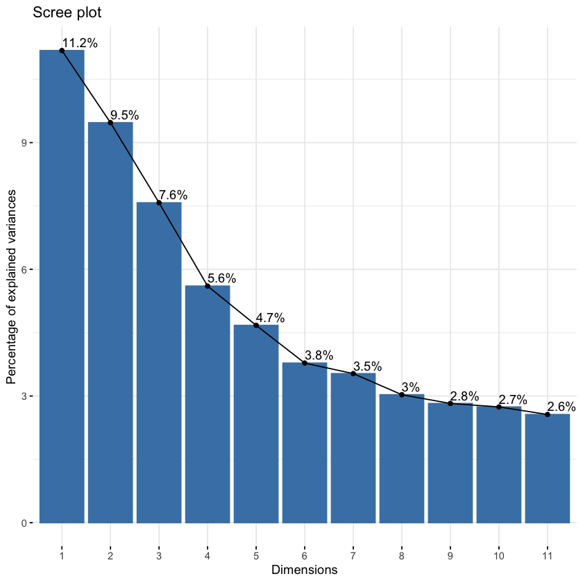

```r
#convert to PCA
numeric_df = personal_mice %>% select(-one_of(factor_col))
head(numeric_df)
pca_facto = PCA(numeric_df, graph = F)
fviz_eig(pca_facto, ncp=11, addlabels = T)
```

Based on the chart above, the "elbow" of the curve is 4 dimensions, thus we decided to reduce the dimensions to only 4.

```r
#set PCA to only have 4 components
pca_facto = PCA(numeric_df,scale.unit = T,ncp = 4,graph = F)

final_pca_data = pca_facto$ind$coord

#merge the data together
final_pca_data = cbind(final_pca_data, personal_mice[,factor_col])
```

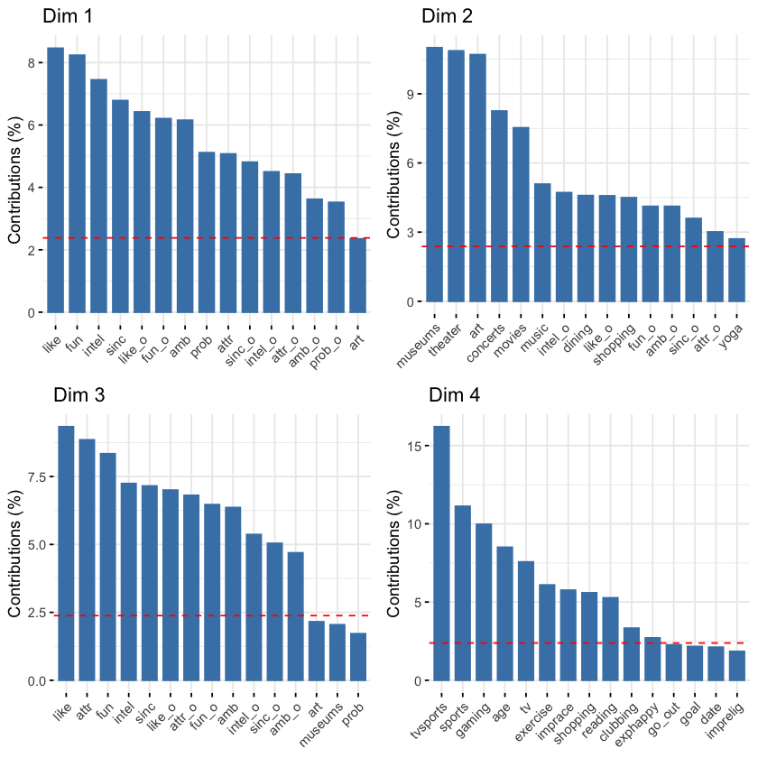

```r
# Look at top 15 contributing factors in each dimension
charts = lapply(1:4,FUN = function(x) fviz_contrib(pca_facto,choice = 'var',axes = x, top=15,title=paste('Dim',x)))
grid.arrange(grobs = charts,ncol=2,nrow=2)
```

```r
#review final data
# final_pca_data[factor_col] <- lapply(final_pca_data[factor_col], factor)

head(final_pca_data)
# write.csv(final_pca_data,"final_pca_data.csv", row.names = FALSE) #write out file
```

A data.frame: 6 × 9

|  | Dim.1 <dbl> | Dim.2 <dbl> | Dim.3 <dbl> | Dim.4 <dbl> | field_cd <fct> | career_c <fct> | match <fct> | race <fct> | gender <fct> |
| --- | --- | --- | --- | --- | --- | --- | --- | --- | --- |
| 1 | 0.1187265 | -2.437169 | -0.43030369 | 1.708820 | 1 | 2 | 0 | 4 | 0 |
| 2 | 0.2459165 | -2.712051 | -0.07870416 | 1.609980 | 1 | 2 | 0 | 4 | 0 |
| 3 | 2.7023518 | -4.562287 | 1.89465094 | 1.690319 | 1 | 2 | 1 | 4 | 0 |
| 4 | 0.5682345 | -2.977258 | 0.23678505 | 1.700148 | 1 | 2 | 1 | 4 | 0 |
| 5 | -0.2386503 | -2.706506 | 0.72746426 | 1.887585 | 1 | 2 | 1 | 4 | 0 |
| 6 | -0.7692568 | -2.311419 | 0.52106682 | 1.916799 | 1 | 2 | 0 | 4 | 0 |

### Closing Remarks and Furthur Examination

This was the first attempt to clean the data, there are several features that could be further cleaned depending on final use for analysis. Examples could be the "from" field which contains differing and multiple locations. Income could potentially be included by cleaning zipcode and comparing to the US Census. Career and Field could also be cleaned further to ensure standardization or simply using the coded fields for generalizations.

### Descriptive Analysis

```r
#average number of successful speed dates
dates <- df %>%
    group_by(iid) %>%
    summarise(match = sum(dec_o), dates = n()) %>%
    mutate(success = 100*match/dates) %>%
    ungroup()
mean(dates$success)
```

42.5109153775932

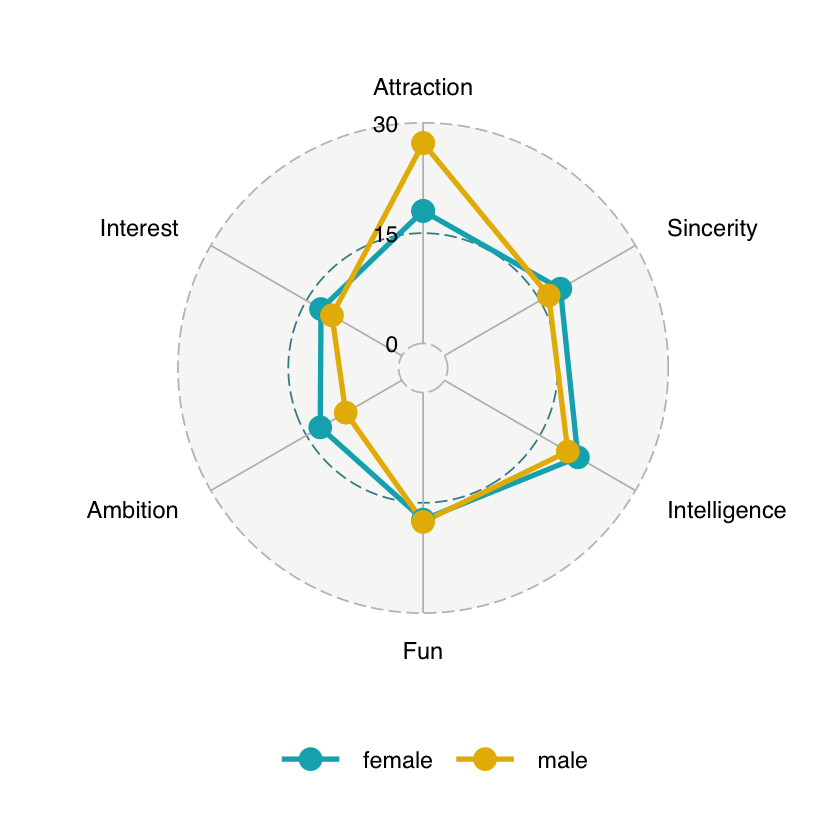

```r
### attributes people look for
tmp2 <- df %>%
    select(ends_with('1_1'), iid, gender) %>%
    filter(!duplicated(iid)) %>%
    group_by(gender) %>%
    summarise_each(funs(round(mean(., na.rm = TRUE),2))) %>%
    ungroup() %>%
        mutate(gender = case_when(
        gender == 0 ~ "female",
        gender == 1 ~ "male",
        TRUE ~ "prefer_not_to_disclose"
    )) %>%
    select(!iid) %>%
    rename(Attraction = attr1_1, Sincerity = sinc1_1, Intelligence = intel1_1, Fun = fun1_1, Ambition = amb1_1, Interest = shar1_1)

ggradar( tmp2,
    values.radar = c('0', '15', '30'),
    grid.min = 0, grid.mid = 15, grid.max = 30,
    group.colours = c("#00AFBB", "#E7B800"),
    legend.position = "bottom"
    )
# colnames(tmp2)

#
# ead(tmp2)
```

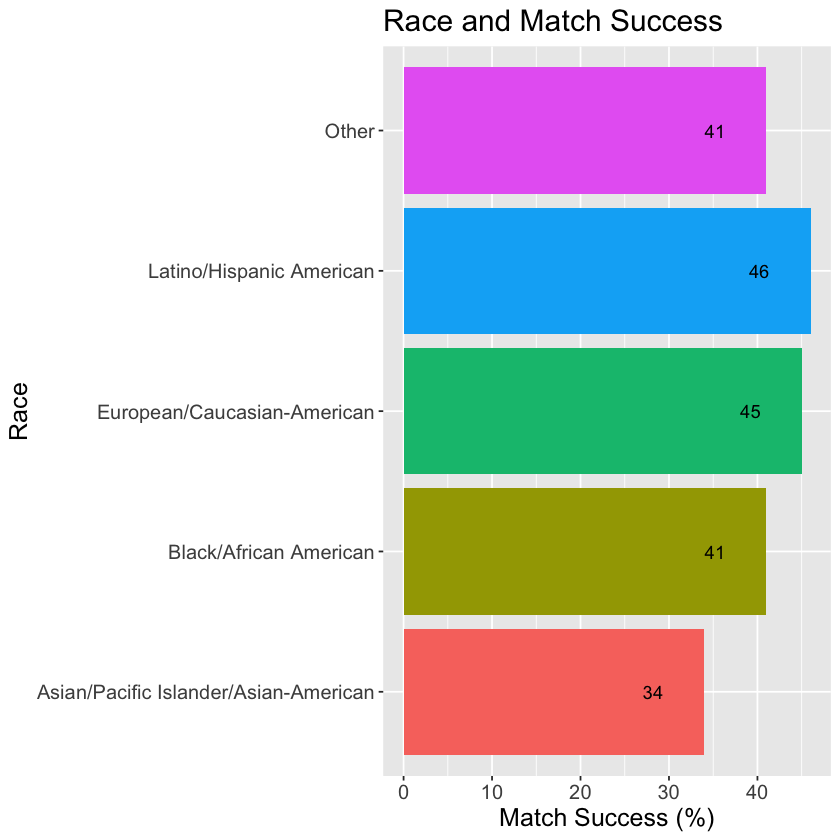

```r
## grid chart of race and successful matches
tmp <- df %>%
    select(iid, race, dec_o) %>%
    mutate(race = case_when(
        race == 1 ~ "Black/African American",
        race == 2 ~ "European/Caucasian-American",
        race == 3 ~ "Latino/Hispanic American",
        race == 4 ~ "Asian/Pacific Islander/Asian-American",
        race == 5 ~ "Native American",
        TRUE ~ "Other" )) %>%
    group_by(race) %>%
    summarise(match = sum(dec_o), dates = n()) %>%
    ungroup() %>%
    mutate(match_success = round(100*match/dates,0))

ggplot(data=tmp, aes(x = factor(race), fill = factor(race), y = match_success)) +
    geom_bar(stat = 'identity') +
    theme(legend.position = "none",
        text = element_text(size = 15)) +
    geom_text(aes(label= match_success), stat = "identity", hjust = 3)+
    coord_flip() +
    ggtitle("Race and Match Success") +
    xlab("Race") + ylab("Match Success (%)")
```

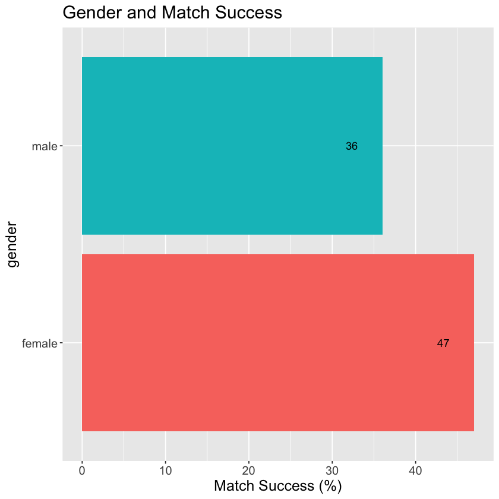

```r
## grid chart of gender and successful matches
tmp <- df %>%
    select(iid, gender, dec_o) %>%
    mutate(gender = case_when(
        gender == 0 ~ "female",
        gender == 1 ~ "male",
        TRUE ~ "prefer_not_to_disclose"
    )) %>%
    group_by(gender) %>%
    summarise(match = sum(dec_o), dates = n()) %>%
    ungroup() %>%
    mutate(match_success = round(100*match/dates,0))

ggplot(data=tmp, aes(x = factor(gender), fill = factor(gender), y = match_success)) +
    geom_bar(stat = 'identity') +
    theme(legend.position = "none",
        text = element_text(size = 15)) +
    geom_text(aes(label= match_success), stat = "identity", hjust = 3)+
    coord_flip() +
    xlab("gender") + ylab("Match Success (%)")+
    ggtitle("Gender and Match Success")
```

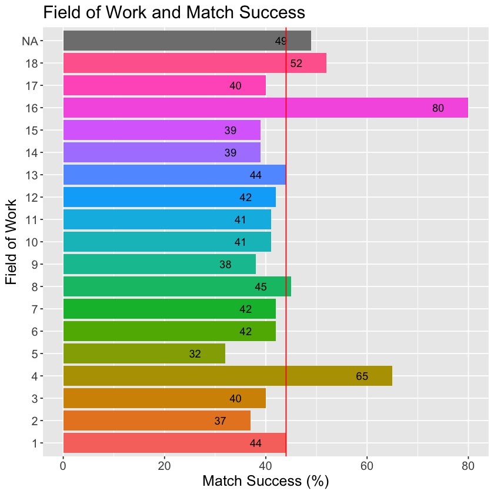

```r
## grid chart of field_cd and successful matches
tmp <- df %>%
    select(iid, field_cd, dec_o) %>%
    group_by(field_cd) %>%
    summarise(match = sum(dec_o), dates = n()) %>%
    ungroup() %>%
    mutate(match_success = round(100*match/dates,0))

# mean(tmp$match_success)
ggplot(data=tmp, aes(x = factor(field_cd), fill = factor(field_cd), y = match_success)) +
    geom_bar(stat = 'identity') +
    theme(legend.position = "none", text = element_text(size = 15)) +
    geom_text(aes(label= match_success), stat = "identity", hjust = 3)+
    coord_flip() +
    geom_hline(yintercept = 44,color="red")+
    xlab("Field of Work") + ylab("Match Success (%)")+
    ggtitle("Field of Work and Match Success")
```

job 16 (languages) and 4 (medical science/pharma/bio) has the most success are most attractive

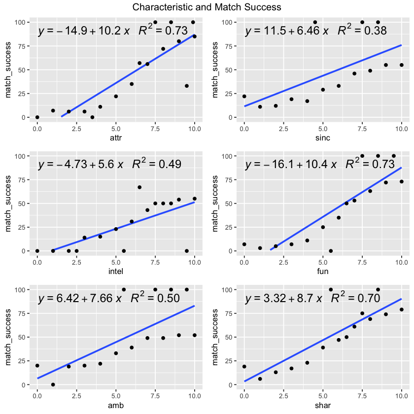

```r
char = c('attr', 'sinc', 'intel', 'fun', 'amb', 'shar')

attr <- suppressWarnings(df %>%
    group_by(attr) %>%
    summarise(match = sum(dec), dates = n()) %>%
    ungroup() %>%
    mutate(match_success = round(100*match/dates,0)) %>%
    na.omit()
    )


attr_g <- suppressWarnings(ggplot(data=attr, aes(x = attr, y = match_success)) +
    geom_smooth(method=lm, se=FALSE, formula = y~x) +
    stat_poly_eq(aes(label = paste(..eq.label.., ..rr.label.., sep = "~~~")),
                 parse = TRUE, size = 5) +
    theme(text = element_text(size = 10)) +
   geom_point() +
    ylim(0, 100))

sinc <- suppressWarnings(df %>%
    group_by(sinc) %>%
    summarise(match = sum(dec), dates = n()) %>%
    ungroup() %>%
    mutate(match_success = round(100*match/dates,0)) %>%
    na.omit()
    )


sinc_g <- suppressWarnings(ggplot(data=sinc, aes(x = sinc, y = match_success)) +
    geom_smooth(method=lm, se=FALSE, formula = y~x) +
    stat_poly_eq(aes(label = paste(..eq.label.., ..rr.label.., sep = "~~~")),
                 parse = TRUE, size = 5) +
    theme(text = element_text(size = 10)) +
   geom_point() +
    ylim(0, 100))

intel <- suppressWarnings(df %>%
    group_by(intel) %>%
    summarise(match = sum(dec), dates = n()) %>%
    ungroup() %>%
    mutate(match_success = round(100*match/dates,0)) %>%
    na.omit()
    )


intel_g <- suppressWarnings(ggplot(data=intel, aes(x = intel, y = match_success)) +
    geom_smooth(method=lm, se=FALSE, formula = y~x) +
    stat_poly_eq(aes(label = paste(..eq.label.., ..rr.label.., sep = "~~~")),
                 parse = TRUE, size = 5) +
    theme(text = element_text(size = 10)) +
   geom_point() +
    ylim(0, 100))

fun <- suppressWarnings(df %>%
    group_by(fun) %>%
    summarise(match = sum(dec), dates = n()) %>%
    ungroup() %>%
    mutate(match_success = round(100*match/dates,0)) %>%
    na.omit()
    )


fun_g <- suppressWarnings(ggplot(data=fun, aes(x = fun, y = match_success)) +
    geom_smooth(method=lm, se=FALSE, formula = y~x) +
    stat_poly_eq(aes(label = paste(..eq.label.., ..rr.label.., sep = "~~~")),
                 parse = TRUE, size = 5) +
    theme(text = element_text(size = 10)) +
   geom_point() +
    ylim(0, 100))

amb <- suppressWarnings(df %>%
    group_by(amb) %>%
    summarise(match = sum(dec), dates = n()) %>%
    ungroup() %>%
    mutate(match_success = round(100*match/dates,0)) %>%
    na.omit()
    )


amb_g <- suppressWarnings(ggplot(data=amb, aes(x = amb, y = match_success)) +
    geom_smooth(method=lm, se=FALSE, formula = y~x) +
    stat_poly_eq(aes(label = paste(..eq.label.., ..rr.label.., sep = "~~~")),
                 parse = TRUE, size = 5) +
    theme(text = element_text(size = 10)) +
   geom_point() +
    ylim(0, 100))

shar <- suppressWarnings(df %>%
    group_by(shar) %>%
    summarise(match = sum(dec), dates = n()) %>%
    ungroup() %>%
    mutate(match_success = round(100*match/dates,0)) %>%
    na.omit()
    )


shar_g <- suppressWarnings(ggplot(data=shar, aes(x = shar, y = match_success)) +
    geom_smooth(method=lm, se=FALSE, formula = y~x) +
    stat_poly_eq(aes(label = paste(..eq.label.., ..rr.label.., sep = "~~~")),
                 parse = TRUE, size = 5) +
    theme(text = element_text(size = 10)) +
   geom_point() +
    ylim(0, 100))

chart = suppressWarnings(grid.arrange(attr_g,sinc_g,intel_g,fun_g, amb_g, shar_g,top="Characteristic and Match Success"))
```

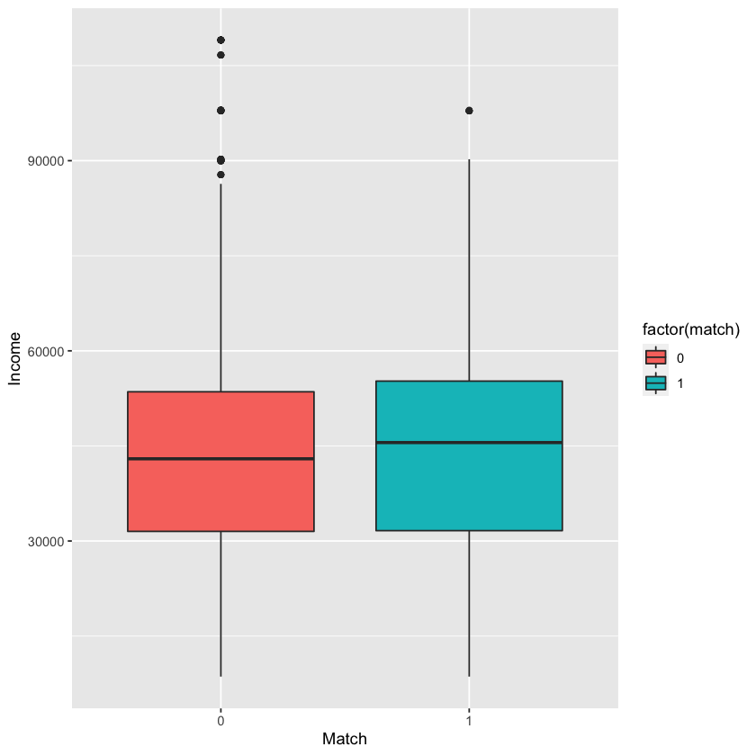

```r
### Income and Match Distribution
df %>%
    select(match,income) %>%
    mutate(income = as.numeric(gsub(",","",income))) %>%
    filter(!is.null(income), income != '') %>%
    ggplot(., aes(x=factor(match), y=  income , fill=factor(match))) +
        geom_boxplot() +
        xlab("Match") + ylab("Income")
        # ggtitle("Gender and Income and Match Distribution")
```

## Model Training

### Splitting the Data

```r
#split data into 2 groups, train, test -- change the data to either use pca or variable importance
set.seed(123)
final_pca_data['match'] <- lapply(final_pca_data['match'], factor)
split = sample.split(final_pca_data$match,SplitRatio = 0.8)
train = final_pca_data[split,]
test = final_pca_data[!split,]
```

### Random Forest Models

```r
#random forest
forest = randomForest(match~.,data=train, method = 'class', ntree = 100)
summary(forest)
```

```
                Length Class  Mode
call                5  -none- call
type                1  -none- character
predicted        6702  factor numeric
err.rate          300  -none- numeric
confusion           6  -none- numeric
votes           13404  matrix numeric
oob.times        6702  -none- numeric
classes             2  -none- character
importance          8  -none- numeric
importanceSD        0  -none- NULL
localImportance     0  -none- NULL
proximity           0  -none- NULL
ntree               1  -none- numeric
mtry                1  -none- numeric
forest             14  -none- list
y                6702  factor numeric
test                0  -none- NULL
inbag               0  -none- NULL
terms               3  terms  call
```

```r
#accuracy in train
confusionMatrix(predict(forest), train$match)
```

```
Confusion Matrix and Statistics

          Reference
Prediction    0    1
         0 5311  768
         1  287  336

               Accuracy : 0.8426
                 95% CI : (0.8336, 0.8512)
    No Information Rate : 0.8353
    P-Value [Acc > NIR] : 0.05447

                  Kappa : 0.3067

 Mcnemar's Test P-Value : < 2e-16

            Sensitivity : 0.9487
            Specificity : 0.3043
         Pos Pred Value : 0.8737
         Neg Pred Value : 0.5393
             Prevalence : 0.8353
         Detection Rate : 0.7925
   Detection Prevalence : 0.9070
      Balanced Accuracy : 0.6265

       'Positive' Class : 0
```

```r
#accuracy in test
pred = predict(forest,newdata=test)
ct = table(test$match,pred);
accuracy = sum(ct[1,1],ct[2,2])/nrow(test); accuracy
```

0.837708830548926

A data.frame: 7 × 3

|  | tree <int> | variable <chr> | minimal_depth <dbl> |
| --- | --- | --- | --- |
| 1 | 1 | Dim.1 | 3 |
| 2 | 1 | Dim.2 | 2 |
| 3 | 1 | Dim.3 | 0 |
| 4 | 1 | Dim.4 | 4 |
| 5 | 1 | career_c | 2 |
| 6 | 1 | field_cd | 1 |
| 7 | 1 | gender | 3 |

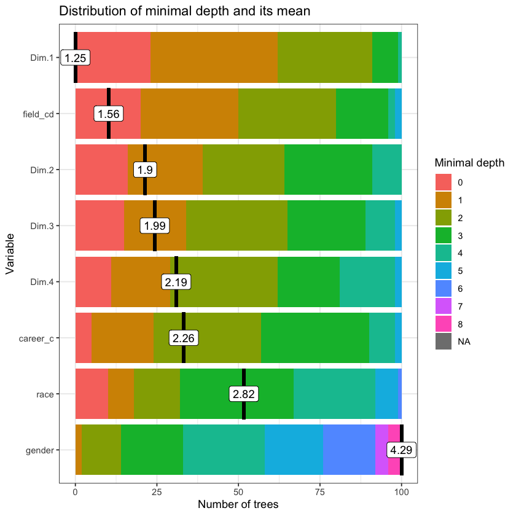

```r
#visualize
#Explain random forest
#install.packages('devtools')
#devtools::install_github("MI2DataLab/randomForestExplainer")
library(randomForestExplainer)

#Minimal depth
#A smaller minimal depth identifies a more predictive variable.
min_depth_frame <- min_depth_distribution(forest)
save(min_depth_frame, file = "min_depth_frame.rda")
load("min_depth_frame.rda")
head(min_depth_frame, n = 7)

# plot_min_depth_distribution(forest)
plot_min_depth_distribution(min_depth_frame)
```

## GBM Model

```r
#change the variable 'match' into binary value
clean_data = final_pca_data %>% mutate(match=recode(match, '0'=0, '1'=1))
str(clean_data)
sum(is.na(clean_data))
```

```
'data.frame':	8378 obs. of  9 variables:
 $ Dim.1   : num  0.119 0.246 2.702 0.568 -0.239 ...
 $ Dim.2   : num  -2.44 -2.71 -4.56 -2.98 -2.71 ...
 $ Dim.3   : num  -0.4303 -0.0787 1.8947 0.2368 0.7275 ...
 $ Dim.4   : num  1.71 1.61 1.69 1.7 1.89 ...
 $ field_cd: Factor w/ 18 levels "1","2","3","4",..: 1 1 1 1 1 1 1 1 1 1 ...
 $ career_c: Factor w/ 17 levels "1","2","3","4",..: 2 2 2 2 2 2 2 2 2 2 ...
 $ match   : num  0 0 1 1 1 0 0 0 1 0 ...
 $ race    : Factor w/ 5 levels "1","2","3","4",..: 4 4 4 4 4 4 4 4 4 4 ...
 $ gender  : Factor w/ 2 levels "0","1": 1 1 1 1 1 1 1 1 1 1 ...
```

0

```r
#summary
train= train %>% mutate(match=recode(match, '0'=0, '1'=1))
str(train)
prop.table(table(train$match)) #This tells us that 16.4% of our data contains 1.
#This is an important step because if the proportion was smaller than 15%, it would be considered a rare event and would be more challenging to model.
```

```
'data.frame':	6702 obs. of  9 variables:
 $ Dim.1   : num  0.119 0.246 0.568 -0.769 0.906 ...
 $ Dim.2   : num  -2.44 -2.71 -2.98 -2.31 -2.62 ...
 $ Dim.3   : num  -0.4303 -0.0787 0.2368 0.5211 -0.7659 ...
 $ Dim.4   : num  1.71 1.61 1.7 1.92 1.63 ...
 $ field_cd: Factor w/ 18 levels "1","2","3","4",..: 1 1 1 1 1 1 1 1 1 1 ...
 $ career_c: Factor w/ 17 levels "1","2","3","4",..: 2 2 2 2 2 2 2 2 2 2 ...
 $ match   : num  0 0 1 0 1 0 0 0 1 0 ...
 $ race    : Factor w/ 5 levels "1","2","3","4",..: 4 4 4 4 4 4 2 2 2 2 ...
 $ gender  : Factor w/ 2 levels "0","1": 1 1 1 1 1 1 1 1 1 1 ...
```

```
        0         1
0.8352731 0.1647269
```

```r
#Model 1: generalized boosted models
library(gbm)
set.seed(617)
boost = gbm(match~.,
            data=train,
            distribution="bernoulli",
            n.trees = 500,
            interaction.depth = 2,
            shrinkage = 0.01,
            cv.folds = 2)
```

```r
#predict using train
pred_train = predict(boost, n.trees=500, type='response',)
Prediction_results=as.factor(ifelse(pred_train>0.8,1,0))
train$match=as.factor(train$match)
confusionMatrix(Prediction_results, train$match) #accuracy=83.54%
```

```
Confusion Matrix and Statistics

          Reference
Prediction    0    1
         0 5598 1103
         1    0    1

               Accuracy : 0.8354
                 95% CI : (0.8263, 0.8442)
    No Information Rate : 0.8353
    P-Value [Acc > NIR] : 0.4949

                  Kappa : 0.0015

 Mcnemar's Test P-Value : <2e-16

            Sensitivity : 1.0000000
            Specificity : 0.0009058
         Pos Pred Value : 0.8353977
         Neg Pred Value : 1.0000000
             Prevalence : 0.8352731
         Detection Rate : 0.8352731
   Detection Prevalence : 0.9998508
      Balanced Accuracy : 0.5004529

       'Positive' Class : 0
```

```r
#predict using test
pred = predict(boost, newdata = test, n.trees = 500)
Prediction_results_test=as.factor(ifelse(pred>0.8,1,0))
confusionMatrix(Prediction_results_test, test$match) #accuracy=83.65%
```

```
Confusion Matrix and Statistics

          Reference
Prediction    0    1
         0 1399  274
         1    1    2

               Accuracy : 0.8359
                 95% CI : (0.8173, 0.8533)
    No Information Rate : 0.8353
    P-Value [Acc > NIR] : 0.4898

                  Kappa : 0.0108

 Mcnemar's Test P-Value : <2e-16

            Sensitivity : 0.999286
            Specificity : 0.007246
         Pos Pred Value : 0.836222
         Neg Pred Value : 0.666667
             Prevalence : 0.835322
         Detection Rate : 0.834726
   Detection Prevalence : 0.998210
      Balanced Accuracy : 0.503266

       'Positive' Class : 0
```

0.846030399742383

499

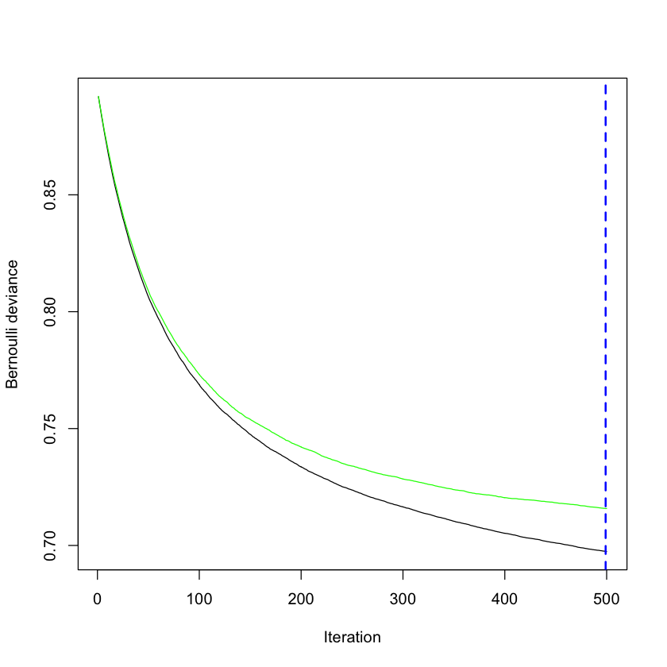

```r
# get MSE and compute RMSE
sqrt(min(boost$cv.error))

# plot loss function as a result of n trees added to the ensemble
gbm.perf(boost, method = "cv")
```

```r
#Model 2: increase n.trees, interaction deepth and cv.folds
train= train %>% mutate(match=recode(match, '0'=0, '1'=1))
set.seed(617)
boost.fit2 <- gbm(
  formula = match~.,
  distribution = "bernoulli",
  data = train,
  n.trees = 1000,
  interaction.depth = 3,
  shrinkage = 0.01,
  cv.folds = 5,
  n.cores = NULL, # will use all cores by default
  verbose = FALSE
)
```

1000

0.840529319789858

1000

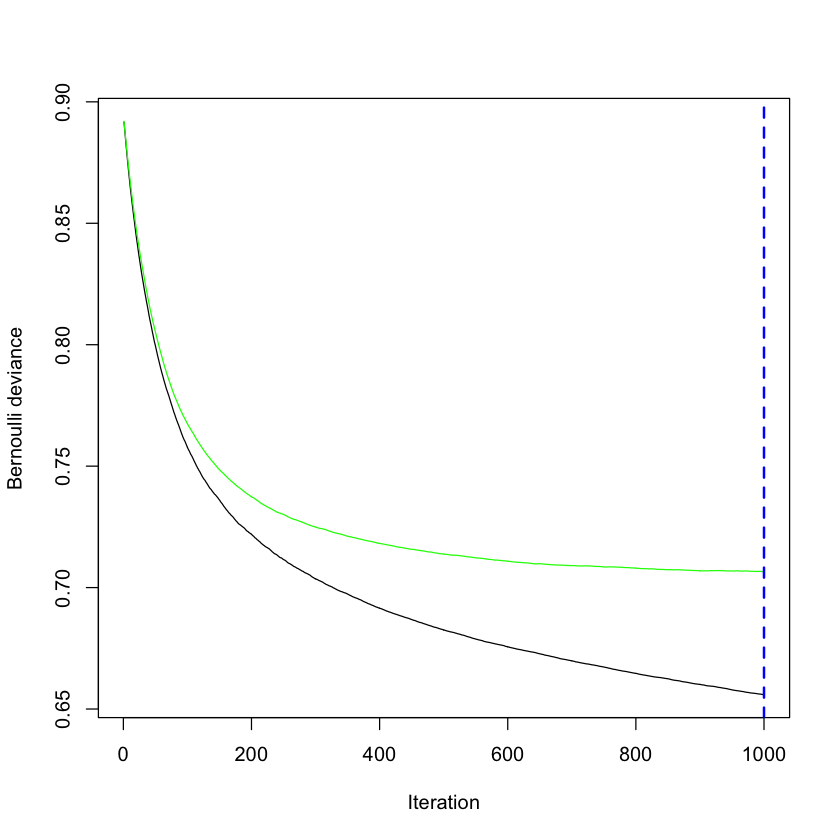

```r
# find index for n trees with minimum CV error
min_MSE <- which.min(boost.fit2$cv.error)
min_MSE

# get MSE and compute RMSE
sqrt(boost.fit2$cv.error[min_MSE])

# plot loss function as a result of n trees added to the ensemble
gbm.perf(boost.fit2, method = "cv")
```

```r
#predict using test
pred_fit2 = predict(boost.fit2, newdata = test, n.trees = 1000)
Prediction_results_test_fit2=as.factor(ifelse(pred_fit2>0.8,1,0))
confusionMatrix(Prediction_results_test_fit2, test$match) #accuracy=84.01%
```

```
Confusion Matrix and Statistics

          Reference
Prediction    0    1
         0 1397  266
         1    3   10

               Accuracy : 0.8395
                 95% CI : (0.821, 0.8568)
    No Information Rate : 0.8353
    P-Value [Acc > NIR] : 0.3365

                  Kappa : 0.0552

 Mcnemar's Test P-Value : <2e-16

            Sensitivity : 0.99786
            Specificity : 0.03623
         Pos Pred Value : 0.84005
         Neg Pred Value : 0.76923
             Prevalence : 0.83532
         Detection Rate : 0.83353
   Detection Prevalence : 0.99224
      Balanced Accuracy : 0.51704

       'Positive' Class : 0
```

A tibble: 6 × 2

| var <chr> | rel.inf <dbl> |
| --- | --- |
| Dim.1 | 57.618183 |
| Dim.2 | 16.581946 |
| field_cd | 10.478304 |
| Dim.3 | 5.581985 |
| career_c | 5.456337 |
| Dim.4 | 2.980426 |

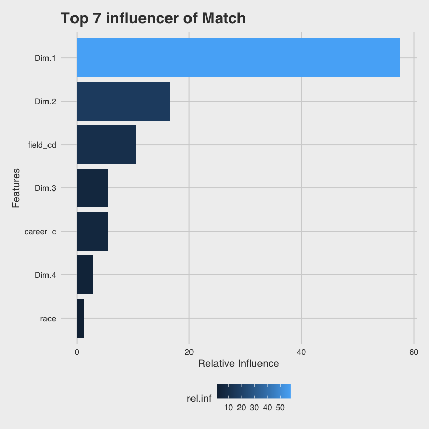

```r
# Best model is boost.fit2 based on the accuracy value
# Visualize
matchEffects <- tibble::as_tibble(gbm::summary.gbm(boost.fit2,
                                                  plotit = FALSE))
matchEffects %>% utils::head()

library(ggthemes)
matchEffects %>%
  # arrange descending to get the top influencers
  dplyr::arrange(desc(rel.inf)) %>%
  # sort to top 10
  dplyr::top_n(7) %>%
  # plot these data using columns
  ggplot(aes(x = forcats::fct_reorder(.f = var,
                                      .x = rel.inf),
             y = rel.inf,
             fill = rel.inf)) +
  geom_col() +
  # flip
  coord_flip() +
  # format
  scale_color_brewer(palette = "Dark2") +
  theme_fivethirtyeight() +
  theme(axis.title = element_text()) +
  xlab('Features') +
  ylab('Relative Influence') +
  ggtitle("Top 7 influencer of Match")
```

## GLM Model

```r
# Using all variables
model2 = glm(match~.,data=train,family='binomial')

pred2 = predict(model2,newdata=test,type='response')
ct2 = table(match = test$match,
            predictions = as.integer(pred2>0.8))

accuracy2 = sum(ct2[1,1],ct2[2,2])/nrow(test);
accuracy2
```

0.837112171837709

```r
rmse2 = sqrt(mean(model2$residuals^2))
rmse2
```

5.26176258597726

```r
imp <- as.data.frame(varImp(model2))
imp <- data.frame(overall = imp$Overall,
           names   = rownames(imp))
imp[order(imp$overall,decreasing = T),]
```

A data.frame: 41 × 2

|  | overall <dbl> | names <chr> |
| --- | --- | --- |
| 1 | 27.03187571 | Dim.1 |
| 2 | 12.57943953 | Dim.2 |
| 31 | 4.51265283 | career_c11 |
| 14 | 4.06570421 | field_cd11 |
| 19 | 3.38416759 | field_cd16 |
| 36 | 2.75302496 | career_c16 |
| 7 | 2.70202320 | field_cd4 |
| 3 | 2.56935949 | Dim.3 |
| 29 | 2.18049931 | career_c9 |
| 5 | 2.15443946 | field_cd2 |
| 27 | 2.07210315 | career_c7 |
| 16 | 2.05846153 | field_cd13 |
| 11 | 1.44829377 | field_cd8 |
| 26 | 1.44263695 | career_c6 |
| 34 | 1.38662988 | career_c14 |
| 17 | 1.34614269 | field_cd14 |
| 4 | 1.22236576 | Dim.4 |
| 32 | 1.11377625 | career_c12 |
| 25 | 1.05990985 | career_c5 |
| 23 | 0.94937333 | career_c3 |
| 12 | 0.88748235 | field_cd9 |
| 35 | 0.87523303 | career_c15 |
| 33 | 0.87036696 | career_c13 |
| 18 | 0.85968063 | field_cd15 |
| 22 | 0.85613841 | career_c2 |
| 40 | 0.66551327 | race6 |
| 38 | 0.64627704 | race3 |
| 9 | 0.63660494 | field_cd6 |
| 30 | 0.59381055 | career_c10 |
| 21 | 0.52340357 | field_cd18 |
| 8 | 0.44922286 | field_cd5 |
| 15 | 0.44357057 | field_cd12 |
| 41 | 0.43705576 | gender1 |
| 24 | 0.32812565 | career_c4 |
| 37 | 0.29292185 | race2 |
| 13 | 0.28097803 | field_cd10 |
| 28 | 0.26018323 | career_c8 |
| 20 | 0.20655783 | field_cd17 |
| 10 | 0.07980093 | field_cd7 |
| 6 | 0.06625119 | field_cd3 |
| 39 | 0.01586398 | race4 |

[figure not shown]

```r
# Draw level of importance graph
ggplot(data=imp[1:7,], aes(x=reorder(names, overall), y=overall)) +
                        geom_bar(stat="identity", fill="steelblue", width = 0.5) +
                        theme(aspect.ratio = .2) +
                        coord_flip() +
                        ggtitle("Top 7 contributing factors") +
                        xlab("Filed Names") +
                        ylab("Level of Importance")
```

## Neural Network Modeling

### Basic neural network

```r
library(nnet)
set.seed(1031)
model1 = nnet(match~.,
             data = train,
             size=5,
             decay=0.1,
             MaxNWts=10000,
             maxit=100)
```

```r
pred = predict(model1,newdata=test,type='class')
mean(pred == test$match)
```

0.827565270188221

#### Tease out factor variables

```r
library(nnet)
set.seed(1031)
model_test = nnet(match~ Dim.1 + Dim.2+ Dim.3 + Dim.4,
             data = train,
             size=5,
             decay=0.1,
             MaxNWts=10000,
             maxit=100)
```

```r
test_test = test[,c(1:4,8)]
head(test_test)
```

A data.frame: 6 × 5

[output not shown]

```r
pred = predict(model_test,newdata=test_test,type='class')
mean(pred == test$match)
```

0.837279902853673

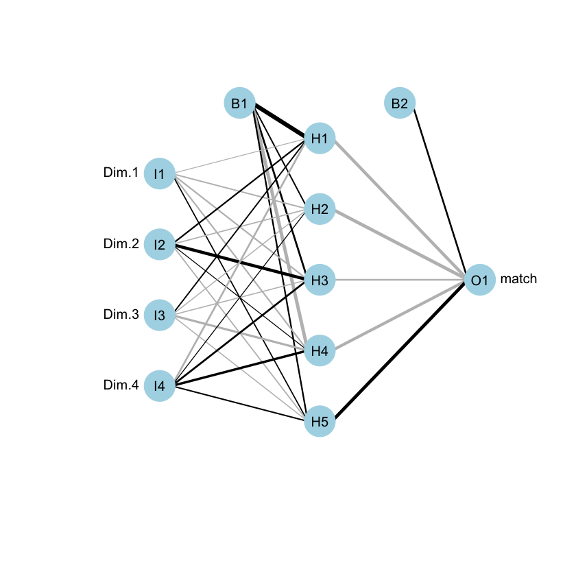

```r
plot(model_test)
```

### Use h2o deep leanring framework

```r
library(h2o)
h2o.init()
```

```
 Connection successful!

R is connected to the H2O cluster:
    H2O cluster uptime:         47 minutes 46 seconds
    H2O cluster timezone:       America/New_York
    H2O data parsing timezone:  UTC
    H2O cluster version:        3.36.0.4
    H2O cluster version age:    23 days
    H2O cluster name:           H2O_started_from_R_hanxuefan_ngc723
    H2O cluster total nodes:    1
    H2O cluster total memory:   1.31 GB
    H2O cluster total cores:    8
    H2O cluster allowed cores:  8
    H2O cluster healthy:        TRUE
    H2O Connection ip:          localhost
    H2O Connection port:        54321
    H2O Connection proxy:       NA
    H2O Internal Security:      FALSE
    R Version:                  R version 4.1.2 (2021-11-01)
```

```r
train_h2o = as.h2o(train)
validation_h2o = as.h2o(validation)
test_h2o = as.h2o(test)
```

```r
model2 = h2o.deeplearning(x=1:7,
                         y = 8,
                         training_frame = train_h2o,
                         hidden = c(5),
                         seed=1031)
```

```r
pred = h2o.predict(model2,newdata = test_h2o)
mean(pred[1]==test_h2o$match)
```

0.804493017607772

#### Tease out factor varianles

```r
model_dim_h2o = h2o.deeplearning(x=1:4,
                         y = 8,
                         training_frame = train_h2o,
                         hidden = c(5),
                         seed=1031)
```

```r
test_h2o_test = test_h2o[,c(1:4,8)]
head(test_h2o_test)
```

A data.frame: 6 × 5

[output not shown]

```r
pred = h2o.predict(model_dim_h2o,newdata = test_h2o_test)
mean(pred[1]==test_h2o_test$match)
```

0.792956891317547

### Maually adjust hyperparameter

```r
model3 = h2o.deeplearning(x=1:7,
                         y = 8,
                         training_frame = train_h2o,
                         hidden = c(10,10),
                         seed=1031)
```

```r
pred = h2o.predict(model3,newdata = test_h2o)
mean(pred[1]==test_h2o$match)
```

0.811778992106861

```r
##hhhh
model3_test = h2o.deeplearning(x=1:4,
                         y = 8,
                         training_frame = train_h2o,
                         hidden = c(10,10),
                         seed=1031)
```

```r
pred = h2o.predict(model3_test,newdata = test_h2o_test)
mean(pred[1]==test_h2o_test$match)
```

0.813600485731633

### Hyperparameter tuning

```r
h2o.init(nthreads = -1)
```

```
 Connection successful!

R is connected to the H2O cluster:
    H2O cluster uptime:         48 minutes 4 seconds
    H2O cluster timezone:       America/New_York
    H2O data parsing timezone:  UTC
    H2O cluster version:        3.36.0.4
    H2O cluster version age:    23 days
    H2O cluster name:           H2O_started_from_R_hanxuefan_ngc723
    H2O cluster total nodes:    1
    H2O cluster total memory:   1.31 GB
    H2O cluster total cores:    8
    H2O cluster allowed cores:  8
    H2O cluster healthy:        TRUE
    H2O Connection ip:          localhost
    H2O Connection port:        54321
    H2O Connection proxy:       NA
    H2O Internal Security:      FALSE
    R Version:                  R version 4.1.2 (2021-11-01)
```

```r
hyper_parameters = list(activation=c('Rectifier','Tanh','Maxout','RectifierWithDropout','TanhWithDropout','MaxoutWithDropout'),
                        hidden=list(c(20,20),c(50,50),c(100,100,100), c(30,30,30),c(50,50,50,50),c(25,25,25,25)),
                        l1=seq(0,1e-4,1e-6),
                        l2=seq(0,1e-4,1e-6))
```

```r
search_criteria = list(strategy='RandomDiscrete',
                       max_runtime_secs=360,
                       max_models=100,
                       seed=1031,
                       stopping_rounds=5,
                       stopping_tolerance=1e-2)
```

```r
grid = h2o.grid(algorithm='deeplearning',
                grid_id='dl_grid_random',
                training_frame = train_h2o,
                validation_frame=validation_h2o,
                x=1:7,
                y=8,
                epochs=10,
                stopping_metric='logloss', # stop when logloss does not improve by more than 1% for 2 scoring events
                stopping_tolerance=1e-2,
                stopping_rounds=2,
                hyper_params = hyper_parameters,
                search_criteria = search_criteria)
```

```r
best_model <- h2o.getModel(grid@model_ids[[1]]) ## model with lowest logloss  (on validation, since it was available during training)
```

```r
h2o.confusionMatrix(best_model,newdata=test_h2o)
pred = h2o.predict(best_model,newdata = test_h2o)
mean(pred[1]==test_h2o$match)
```

A H2OTable: 3 × 4

[output not shown]

0.765027322404372

#### Even lower... interesting...